# Indian Food Nutrient Analysis

Gagan Shehra, Rishikesh Utthari, MD Danish, Shinajan Goswami, Omhari Indoria, Pawan Kumar

Indian Statistical Institute

## Dataset & Cleaning

- Nutrition dataset: It lists amounts of nearly 40 nutrients and minerals (in different units) for 1014 dishes (mostly Indian)
- Data present in two forms:
1. Per 100g
2. Unit serving
- Recipes dataset: 13 variables; 1218 unique ingredients for 1014 food items
- Sourced from official journals (ICMR, CoFID) and blog posts
- Handled data cleaning cases like uppercase and lowercase mismatches
- Created multiple regex patterns (regular expressions) to create the categories,

```
1. food_category
```

```
  bread   curry dessert  drinks    main  others  salads
     54     120     263      74     334     116      53
```

```
2. non_veg
```

```
non_veg     veg
    289     725
```

using `grepl()` (in base package; handles missing values)

- Both of the categories are exclusive and exhaustive

## Ingridients

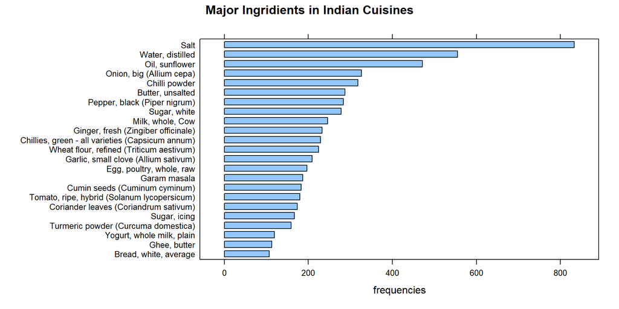

Items like:

are among the dominant ingredients (with frequency > 100) in the 1014 items. Whereas, non-veg items e.g., chicken, meat etc. are not among them. Only egg is a frequent non-veg ingredient in the Indian cuisines.

**Is there a significant correlation between carbohydrate content `carb_g` and fat content `fat_g` across prepared Indian dishes (excluding pure condiments)?**

```
Correlation between carbohydrates and fats (per unit serving) is 0.08063576
```

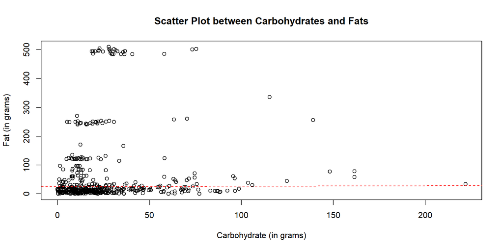

**In the `Desserts` category, does a 1-gram increase in `freesugar_g` predict a significant decrease in a composite Micronutrient Density Score (using `iron_mg`, `calcium_mg`, `magnesium_mg`)?**

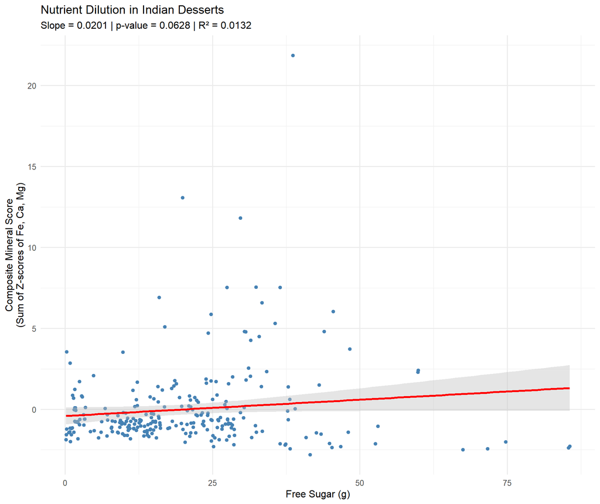

**How do the average cholesterol content `cholesterol_mg` and average saturated fat content `sfa_mg` compare between Egg-based desserts and Eggless desserts?**

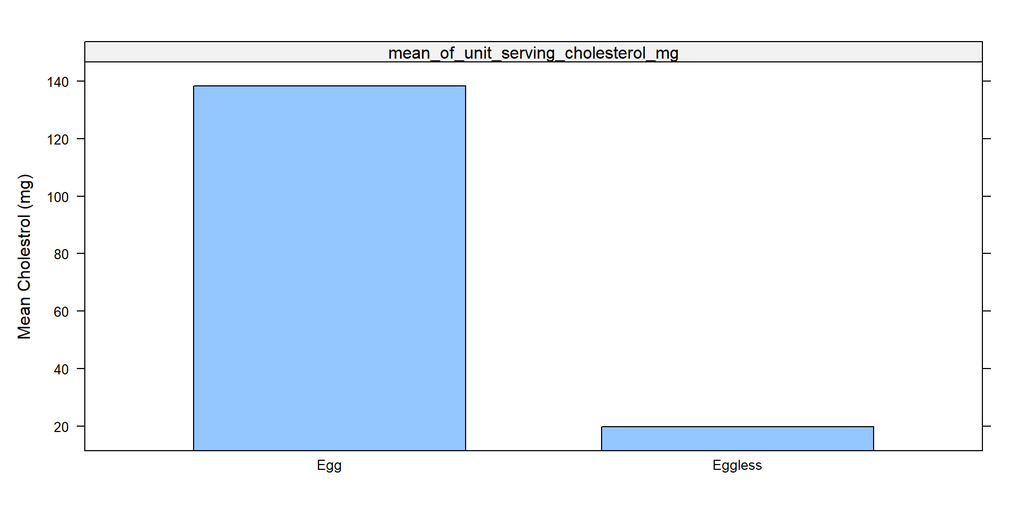

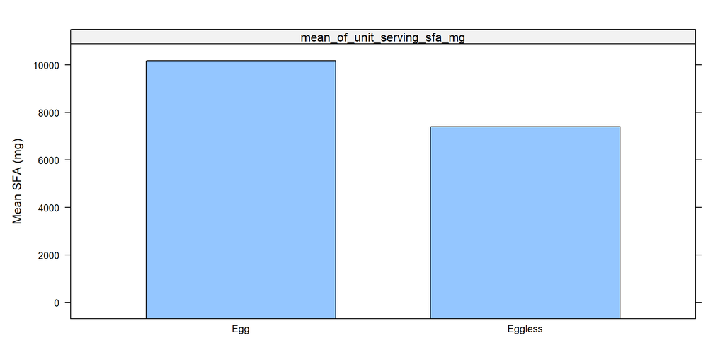

**What is the skewness of the sodium_mg distribution across all savory items? Does a long right tail indicate that the average sodium content is misleading?**

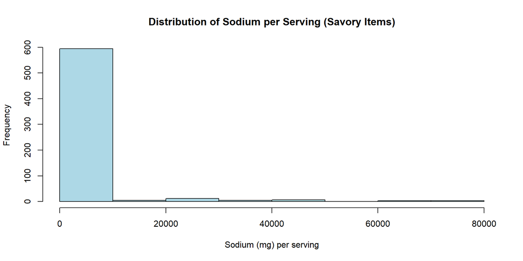

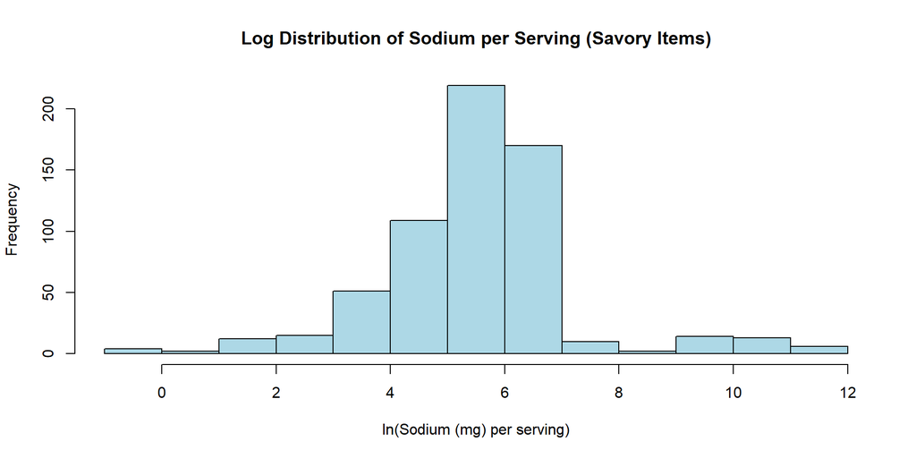

The sodium content across savory dishes is highly right‑skewed (skewness using moments = 5.8) as seen in mean/median ratio (> 8.5). For sodium per serving in savory items, $median (245.7 mg) < mean (2163.5 mg)$ due to the few outliers. Using IQR rule for outliers, there are 53 (and zero) upper (and lower) outliers out of the 681 items. The outliers include pickles, chutneys, items with chaat masala dressing, and certain papads which are often consumed in small quantities but pack high amount of sodium.

## RDA thresholds for the cuisines

**What proportion of Vegetarian Dishes provide less than 15% of the Daily Calcium Requirement (i.e., < 150 mg per serving)?**

```
Vegetarian main dishes with <150mg calcium: 289 out of 372
```

```
Proportion: 77.7 %
```

```
Top 10 vegetarian dishes by calcium:
```

```
                                       food_name unit_serving_calcium_mg
199                                 Methi chaman                606.5990
514                      Lasagne with vegetables                577.8931
355                         Paneer shaslik/tikka                543.3331
592                     Vegetable and cheese pie                482.3165
924                              Gujarati handvo                475.1353
208                         Paneer makhana korma                442.4600
183                           Paneer kofta curry                417.0344
591                        Cauliflower au gratin                402.5615
512 Spaghetti with paneer balls and tomato sauce                400.2536
814     Kidney bean sandwich with cottage cheese                399.4179
```

Odds of a veg staple food having calcium < 150 mg (15% of RDA) per serving = 3.48. Most of the items are calcium deficient. Paneer and leafy greens are the exceptions in calcium levels.

**Which specific dishes provide >20% of the Adequate Intake for Biotin (vitb7_ug > 6 μg) per serving?**

```
21.3 % of dishes provide ≥6 mcg biotin per serving
```

```
Top 10 biotin-rich dishes:
```

```
                     food_name unit_serving_vitb7_ug
853            Egg in a pepper             101.99590
875             Masala souffle              73.38536
223           Tandoori chicken              49.26312
355       Paneer shaslik/tikka              27.12892
381        Hot spinach souffle              26.92472
397             Pineapple cake              25.06400
60  Stuffed egg omelette/omlet              23.64495
855        Corn omelette/omlet              23.54786
378         Hot cheese souffle              23.51472
379         Hot potato souffle              22.33472
```

FATS PROFILE OF FOOD ITEMS

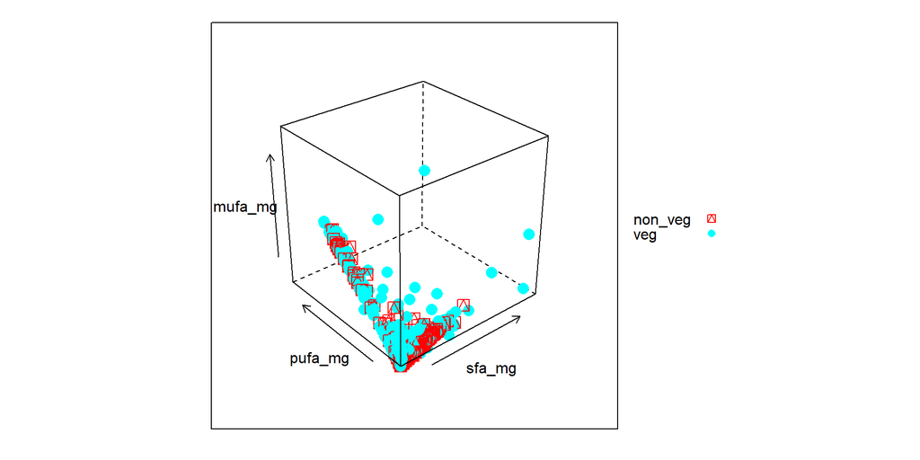

**FATS RICH**

```
1. SFA (bad for health)
others
main
drinks
```

```
2. PUFA (good for health)
drinks
dessert
curry
```

```
3. MUFA (good for health)
main
dessert
drinks
```

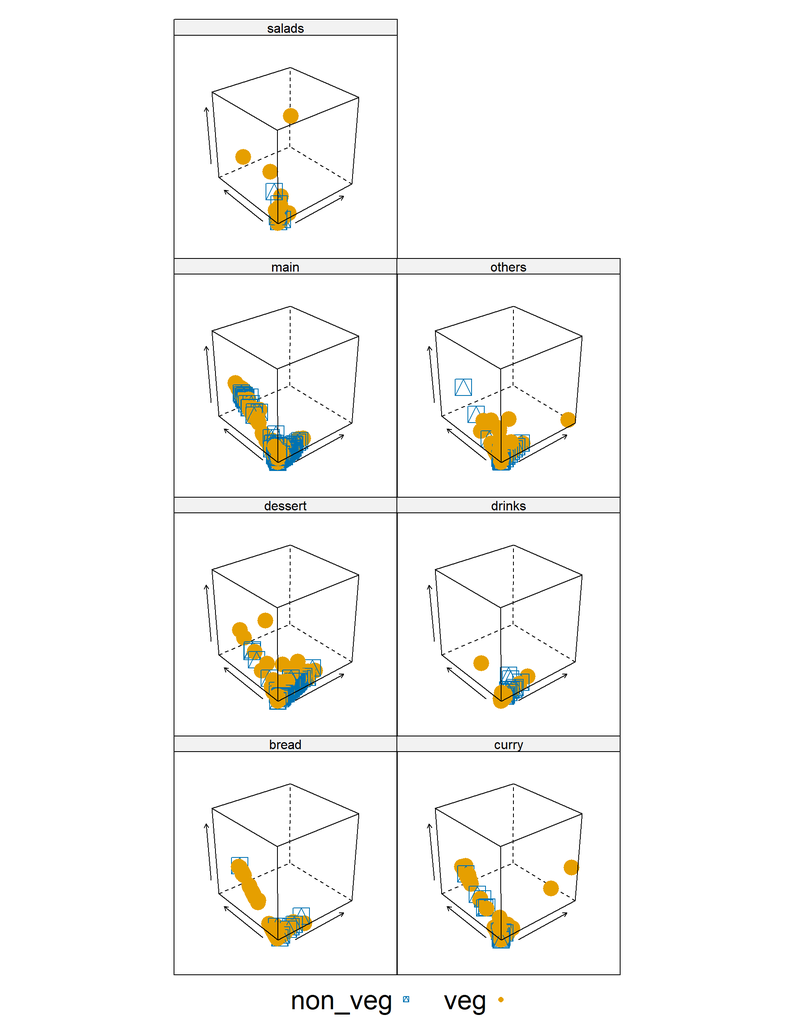

## Boxplots

**Sodium concentration in different food categories**

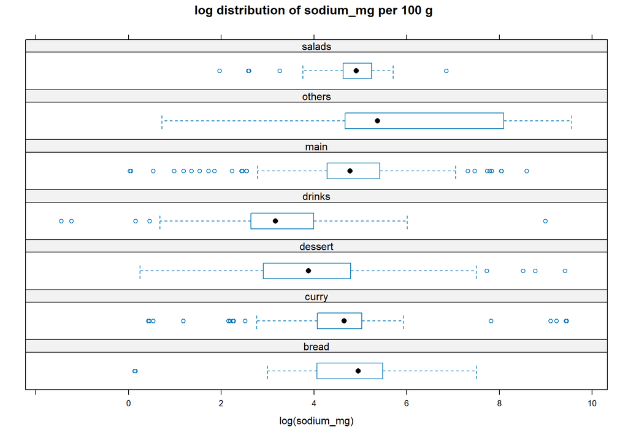

*Salads* are the third highest contributor of sodium in Indian diet. This cooling agent is a significant source of hidden sodium.

Q. **Does raw or cooked food retain vitamin C?**

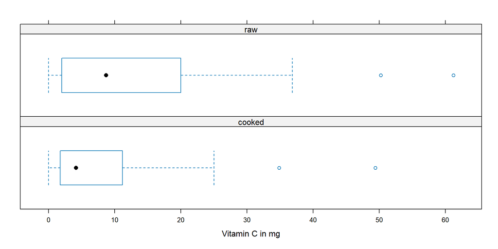

Vitamin C is heat-labile. *Raw* add-ons (pickle, chutney, preserves etc.) are beyond taste— they’re a crucial Vitamin C supplement over *cooked* supplements (like, sauce, soup and ketchup).

## A Vegetarian Paradox

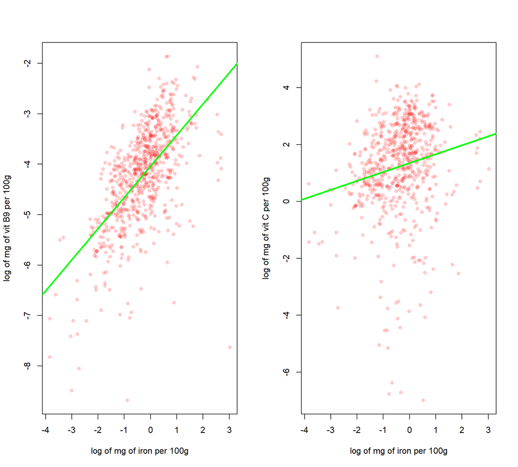

```
correlation b/w vitamin B9 & iron:  0.288952
```

```
correlation b/w vitamin C & iron:  0.02153225
```

While vegetarian meals are adequate in iron and folate (B9) on paper, the heat-labile Vitamin C needed to absorb that iron is largely absent.

Q. **Is there a positive Spearman correlation between fat_g and carotenoids_ug?**

```r
print(head(results[order(-results$cor_car_fat),],3))
```

```
# A tibble: 3 × 2
  type           cor_car_fat
  <chr>                <dbl>
1 veg.curry           0.0199
2 veg.drinks          0.0175
3 non_veg.drinks     -0.0132
```

Carotenoids are fat soluble photosynthetic pigments (found in carrots, pumpkin etc.). Veg curry and veg drinks naturally provide enough fats needed for its absorption; but they are weakly correlated. The overall carotenoids absorption in Indian diet is not very good.

## More Questions

**Do high-fiber foods `fibre_g` in the dataset show a weaker correlation with `zinc_mg` and `iron_mg` compared to their correlation with `magnesium_mg` and `calcium_mg`?**

```
     Nutrients  fibre_mg
1      zinc_mg 0.4595264
2      iron_mg 0.6655711
3 magnesium_mg 0.7793584
4   calcium_mg 0.1746590
```

The strong correlation between-

comes from the presence of whole grains and lentils, as plant-based ingredients naturally package high dietary fiber with magnesium, iron and zinc. The fiber-calcium correlation drops significantly because the dominant sources of calcium i.e., milk, yogurt, and *paneer*, contain negligible fiber.

**What proportion of foods in the entire database contain zero detectable Vitamin A?**

```
  Foods with zero Vitamin A: 370 out of 1014
```

```
  Proportion: 36.5 %
```

**Which food category provides the highest calcium per 100 kcal?**

`Calcium Density` = $(calcium / energy) * 100$

```
                                              food_name calcium_density
610                                        Bathua raita   0.00005688564
609                      Spinach raita (Palak ka raita)   0.00004064860
878                                    Pav bhaji masala   0.00003832947
254                       Mint raita (Pudinay ka raita)   0.00003832319
872            Green chilli raita (Hari mirch ka raita)   0.00003764758
253 Carrot and spinach raita (Gajar aur palak ka raita)   0.00003763235
605                                       Curd dressing   0.00003704342
251           Bottle gourd raita (Ghiya/Lauki ka raita)   0.00003683283
252                    Cucumber raita (Kheere ka raita)   0.00003515801
607                      Pumpkin raita (Kaddu ka raita)   0.00003510138
```

The items with high calcium desnity are *raitas*. *Raitas* have higher alcium density than milk/*paneer* because heat loss takes place during fermentation (of milk to curd).

## More Questions

**Is there a strong positive Pearson correlation between PUFA and vitamin E across all food items?**

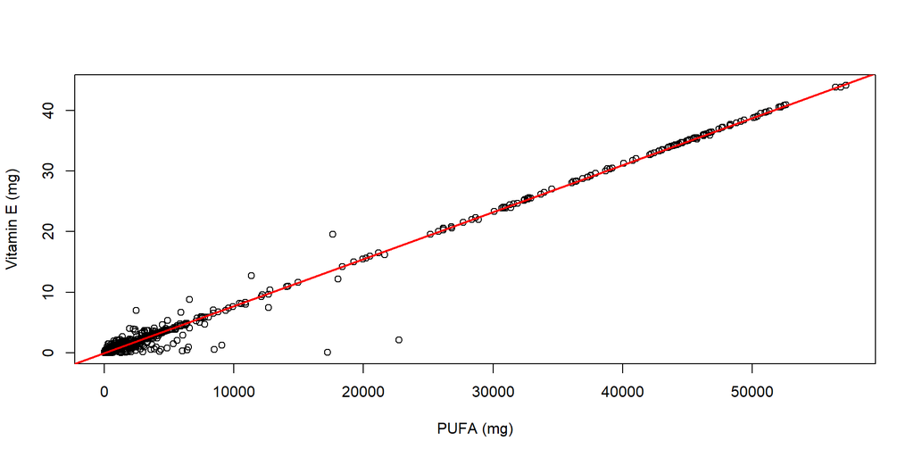

```
The correlation is: 0.9961707
```

Vitamin E is a fat-soluble antioxidant that protects PUFA from oxidation. A strong correlation confirms that nature packages them together.

**Comapre the Protein-to-Energy Ratio of veg and non-veg meals.**

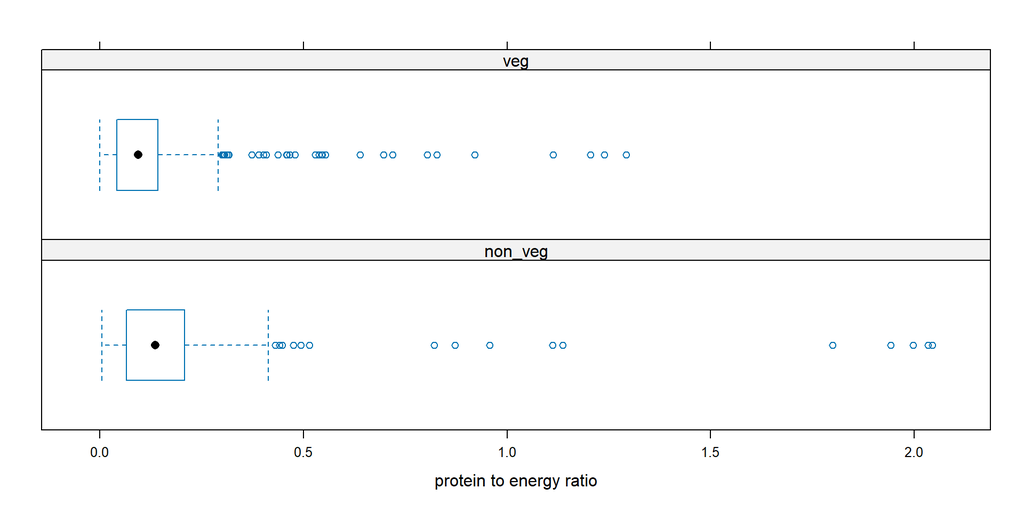

```
                       food_name  pe_ratio
469 Spinach soup (Palak ka soup) 1.2931562
70                   Lentil soup 1.2389593
471                  Cheese soup 1.2047561
930 Classic seasoned black beans 1.1129443
470         Mixed vegetable soup 0.9202681
472            Mulligatawny soup 0.8279547
915                  Millet soup 0.8045939
914     Curried Cauliflower soup 0.7196672
85       Cold summer garden soup 0.6970480
474       Cream of broccoli soup 0.6390642
```

Vegetarian food needs to be served with the above mentioned extra items rich in protein to match the protein efficiency of non-veg meals.

## Which food types are protein rich?

Zinc and copper compete for the same binding protein in the gut. Taking too much zinc (without enough protein to help clear it) can cause the body to “trap” copper in the gut, leading to a copper deficiency. Otherwise, zinc deficiency happens. Hence, *main, bread and dessert* are safe to eat to ensure `copper-zinc balance` and efficient `protein absorption`. The bar-chart denotes the percentage of *sources of protein* (as defined by FSSAI) by taking into consideration the required percentage (for solids and liquids) of RDA value for men and women separately (published by ICMR, MoHFW, Gov. of India). Due to lower RDA, the bars (in the plot) for women are higher than for men.

```
For adult males, any typical food category contributes around 3.547636 to 12.68643 percentage of protein sources. Whereas, it is around 4.92034 to 13.69436 percentage with 95% confidence for adult females.
```

```
Even though women have a higher mean protein percentage than men ( 9.307349 > 8.117035 ) ,their CV is lower ( 0.5096515 < 0.6086847 ). Thereby, the protein contribution is more balanced across the food types for women.
```

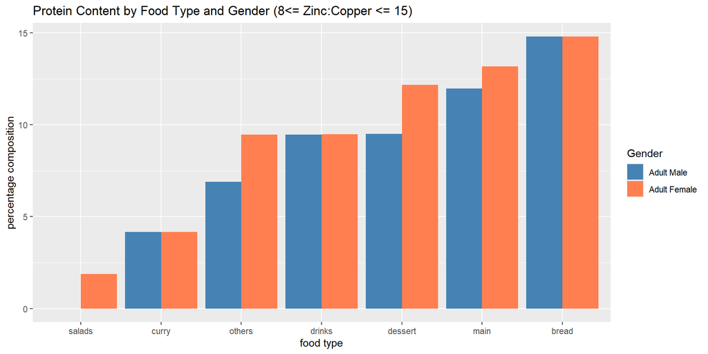

## Limitations

1. Misclassification across food categories due to keyword-based classificastion (Regex pattern and grepl()).
2. Fixed serving sizes assumed for all foods which may ignore real world portion variation.
3. Nutrient thresholds derived from adult requirements only.
4. Assumed linear relationships between nutrients.
5. Single‑food analysis ignores meal context and bioavailability.
6. According to FSSAI, a liquid source of protein should have atleast 5% of RDA per 100 ml. But the dataset contained amounts either for per 100g or per serving of a food item.